# Assignment 3

Søren Orm Hansen

13/11/2019

## Portfolio exam - Part 3

#### Write a short data analysing report on the data colected using the Reading Time Experiment from Portifolio exam - Part 2

First of all, I have to import the Reading Time Data - collected by having 25 participants (9 receiving stimulus 1 and 16 receiving stimulus 2) go through the Reading Time Experiment from Portfolio Exam - part 2, and the MRC data set:

```r
#getting a list of the file names
files <- list.files(path = "logfiles",
                    pattern = ".csv",
                    full.names = T)

#loading the data
data <- lapply(files, read.csv) %>%
  rbind.fill()

#correcting errors
data1 <- data %>% filter(is.na(Reaction.time)) %>% dplyr::rename(rt = "Reaction_Time") %>%
  select(-Reaction.time)
data2 <- data %>% filter(is.na(Reaction_Time)) %>% dplyr::rename(rt = "Reaction.time") %>%
  select(-Reaction_Time)
df <- rbind(data1, data2)

#reading the MRC data set
MRC <- read.csv("MRC_database.csv", header = TRUE, sep = ",")
```

Then I have to tidy up the data a bit, and merge the Reading Time dataset withe the MRC dataset:

```r
#changing the collum name
colnames(df)[colnames(df)=="Word"] <- "word"

#removing punctuation
df$word <- str_replace_all(df$word, pattern="[.'?+’,:‘;-]", replacement="")

#making the letters capital
df$word<- toupper(df$word)

#merging the two data sets
dfM <- merge(df, MRC, by = "word")
```

Let’s have a look at the data:

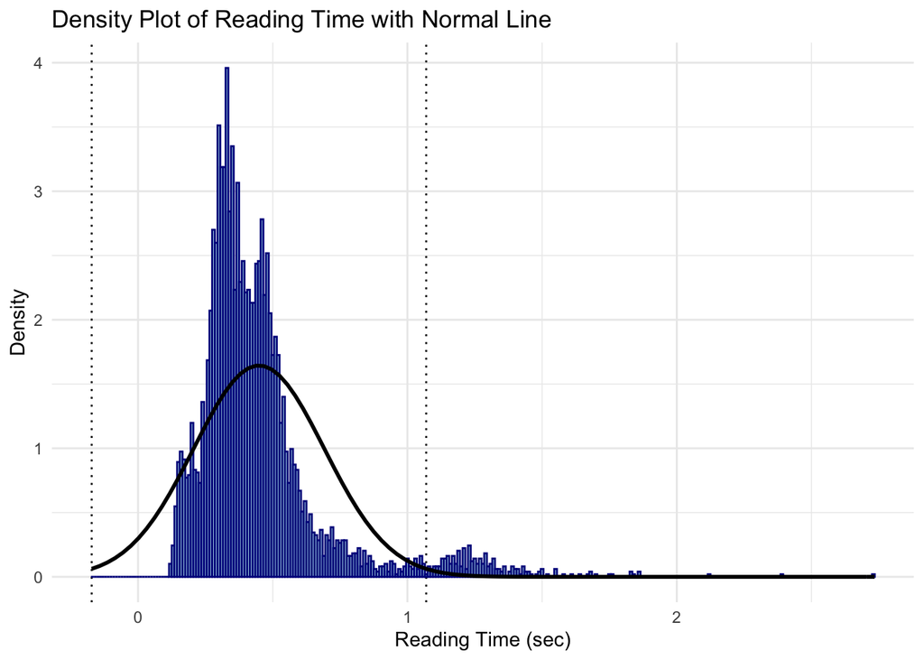

```r
#histogram
ggplot(dfM, aes(x = rt)) +
  geom_vline(data=dfM,
             aes(xintercept = mean(rt)+2.56*sd(rt)),
             colour="black",
             linetype="dotted") +
  geom_vline(data=dfM,
             aes(xintercept = mean(rt)-2.56*sd(rt)),
             colour="black",
             linetype="dotted") +
  geom_histogram(
    aes(y = ..density..),
    color = "darkblue",
    fill = "lightblue",
    binwidth = .01
  ) +
  stat_function(
    fun = dnorm,
    args = list(
      mean = mean(dfM$rt, na.rm = TRUE),
      sd = sd(dfM$rt, na.rm = TRUE)
    ),
    colour = "black",
    size = 1
  ) +
  labs(title = "Density Plot of Reading Time with Normal Line",
           y = "Density",
           x = "Reading Time (sec)"
           ) +
  theme_minimal()
```

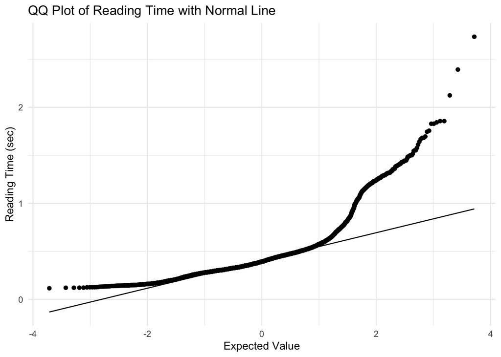

```r
#QQ-plot
ggplot(dfM, aes(sample = rt)) +
  stat_qq() +
  stat_qq_line() +
  labs(title = "QQ Plot of Reading Time with Normal Line",
       y = "Reading Time (sec)",
       x = "Expected Value"
       ) +
  theme_minimal()
```

The data is non-normal with a heavy positive skew, but that is to be expected when dealing with reaction (reading) time data.

##Part 1: Which properties of words correlate with word-by-word reading times?

I will conduct three iterations of correlation analysis, each addressing one of the following three word properties: word length, word frequency, and word number.

####First iteration

First, I’ll conduct a correlation analysis between reading times and word length.

Since the word lenght is a discrete variable and not a continious variable, I will use the non-parametric Spearman’s test for correlation on the non-normally distributed reading time data:

```r
#spearman's correlation test
cor.test(dfM$nlet, dfM$rt, method = "spearman")
```

```
##
##  Spearman's rank correlation rho
##
## data:  dfM$nlet and dfM$rt
## S = 1.9754e+10, p-value = 0.5818
## alternative hypothesis: true rho is not equal to 0
## sample estimates:
##         rho
## 0.007850745
```

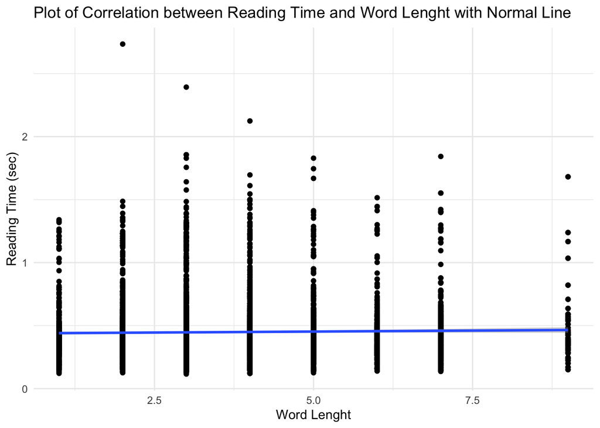

```r
#scatter plot of the data from the correlation test
ggplot(dfM, aes(nlet, rt)) +
  geom_point() +
  geom_smooth(method = lm) +
  labs(title = "Plot of Correlation between Reading Time and Word Lenght with Normal Line",
           y = "Reading Time (sec)",
           x = "Word Lenght"
           ) +
  theme_minimal()
```

The time it took to read a given word was found to be insignificantly correlated with the length of the word, r(4923) =0.008, p > .05.

####Second iteration

Second, I’ll conduct a correlation analysis between reading times and word frequencies:

In the MRC data set, there are two different measurements of written word-frequencies; Kucera-Francis (kf) and Thorndike-Lorge (tl). The text our reading time data is based on contains words that are not present in neither the kf corpus nor in the tl corpus (the words, that have a frequency of 0). Naturally, I will chose the corpus with the biggest overlap with the text the reading time data is based on.

```r
#selecting the observations where kf=0
kf_freq <- filter(dfM, kf_freq == 0)

#selecting the observations where tl=0
tl_freq <- filter(dfM, tl_freq == 0)

#number of observations where kf=0 divided by the number of participants
length(kf_freq$X)/25
```

```
## [1] 4
```

```r
#number of observations where tl=0 divided by the number of participants
length(tl_freq$X)/25
```

```
## [1] 15
```

It was found, that the kf corpus contains biggest overlap with the text used in the experiment (kf contains 4 words without a frequency compared with the tl, that contains 15 words without a frequency).

I will now remove the words, that does not have a frequency in the kf corpus:

```r
#removing the observations without a kf frequency
freq_cor <- filter(dfM, kf_freq > 0)
```

Let’s look at the distribution of the frequencies:

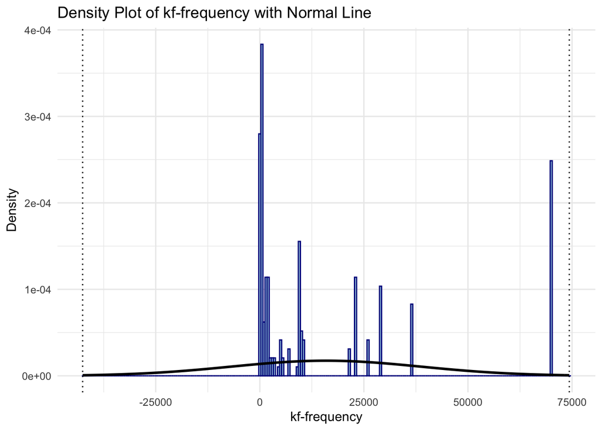

```r
#histogram
ggplot(freq_cor, aes(x = kf_freq)) +
  geom_vline(data=freq_cor,
             aes(xintercept = mean(kf_freq)+2.56*sd(kf_freq)),
             colour="black",
             linetype="dotted") +
  geom_vline(data=freq_cor,
             aes(xintercept = mean(kf_freq)-2.56*sd(kf_freq)),
             colour="black",
             linetype="dotted") +
  geom_histogram(
    aes(y = ..density..),
    color = "darkblue",
    fill = "lightblue",
    binwidth = 500
  ) +
  stat_function(
    fun = dnorm,
    args = list(
      mean = mean(freq_cor$kf_freq, na.rm = TRUE),
      sd = sd(freq_cor$kf_freq, na.rm = TRUE)
    ),
    colour = "black",
    size = 1
  ) +
  labs(title = "Density Plot of kf-frequency with Normal Line",
           y = "Density",
           x = "kf-frequency"
           ) +
  theme_minimal()
```

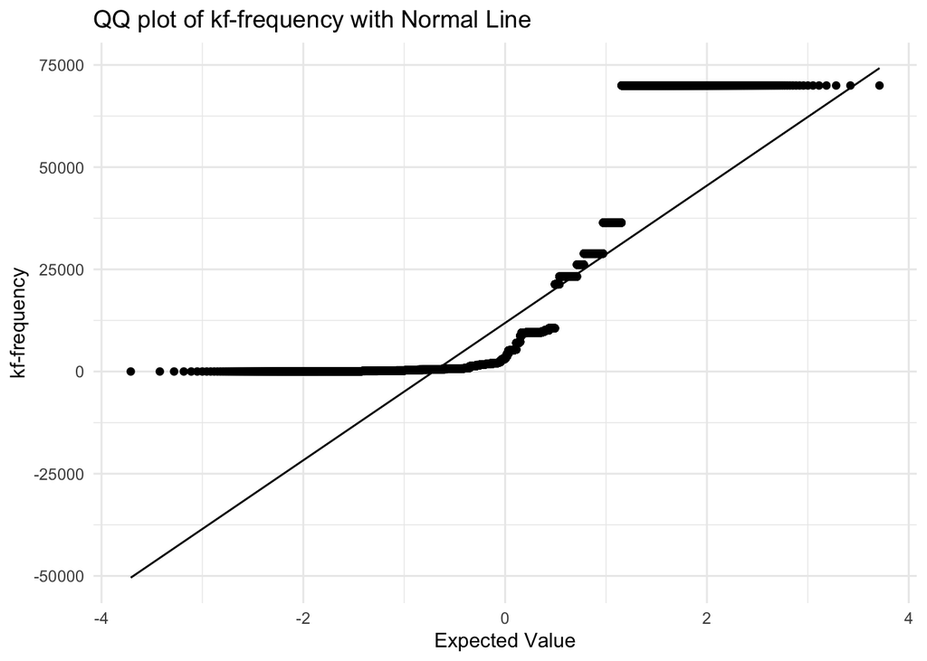

```r
#QQ-plot kf-freq
ggplot(freq_cor, aes(sample = kf_freq)) +
  stat_qq() +
  stat_qq_line() +
  labs(title = "QQ plot of kf-frequency with Normal Line",
       y = "kf-frequency",
       x = "Expected Value"
       ) +
  theme_minimal()
```

Since the kf-frequencies are not normally distributed (the data obviously doesn’t look normal and there are too many observations to run a meaningful test for normality), I will use the Spearman’s test for correlation:

```r
#spearman's correlation test
cor.test(freq_cor$kf_freq, freq_cor$rt, method = "spearman")
```

```
##
##  Spearman's rank correlation rho
##
## data:  freq_cor$kf_freq and freq_cor$rt
## S = 1.9064e+10, p-value = 0.2042
## alternative hypothesis: true rho is not equal to 0
## sample estimates:
##        rho
## -0.0182819
```

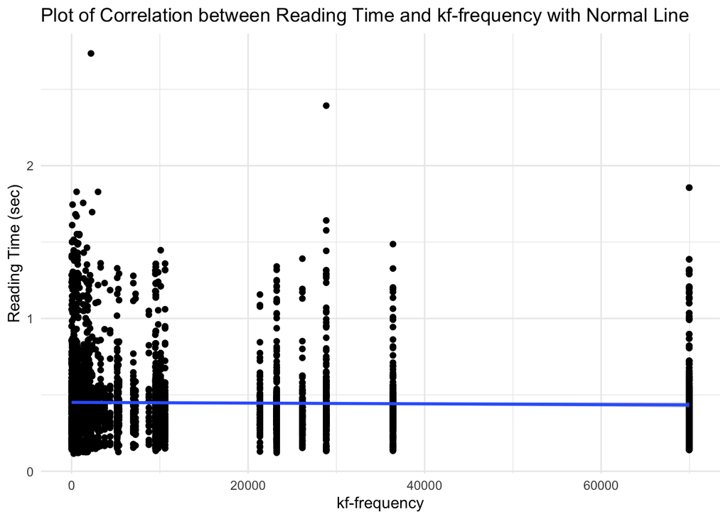

```r
#scatter plot of the data from the correlation test
ggplot(freq_cor, aes(kf_freq, rt)) +
  geom_point() +
  geom_smooth(method = lm) +
  labs(title = "Plot of Correlation between Reading Time and kf-frequency with Normal Line",
           y = "Reading Time (sec)",
           x = "kf-frequency"
           ) +
  theme_minimal()
```

The time it took to read a given word was found to be insignificantly correlated with the kf-frequnecy of the word, r(4823) =-0.018, p > .05.

####Word Number

Third, I’ll conduct a correlation analysis between reading time and when the word occured in the text:

Since the word number is a discrete variable and not a continuous variable, I will use the non-parametric Spearman’s test for correlation on the non-normally distributed reading time data:

```r
#spearman's correlation test
cor.test(dfM$X, dfM$rt, method = "spearman")
```

```
##
##  Spearman's rank correlation rho
##
## data:  dfM$X and dfM$rt
## S = 2.1477e+10, p-value = 3.211e-08
## alternative hypothesis: true rho is not equal to 0
## sample estimates:
##         rho
## -0.07869038
```

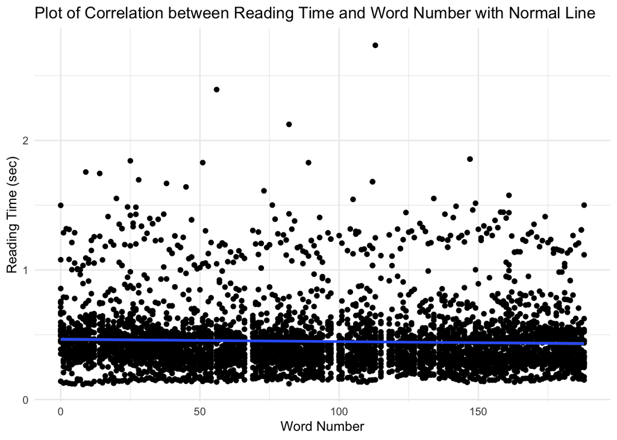

```r
#scatter plot of the data from the correlation test
ggplot(dfM, aes(X, rt)) +
  geom_point() +
  geom_smooth(method = lm) +
  labs(title = "Plot of Correlation between Reading Time and Word Number with Normal Line",
           y = "Reading Time (sec)",
           x = "Word Number"
           ) +
  theme_minimal()
```

The time it took to read a given word was found to be significantly correlated with how late the word appeared in the text, r(4923) = -0.079, p < .001.

##Part 2: How do semantic-contextual expectations affect reading times?

I will conduct a contrastive analysis of the two conditions in your reading experiment (where condition #2 corresponds to the text with the semantically surprising word - bees making juice instead of honey). I will single out the specific reading time for the target words (honey and juice) as well as the following word. I will compare the means of the reading times for those words (independently) across conditions using the appropriate type of t-test.

The salient word in the reading time experiment was bees making ‘juice’ instead of ‘honey’. Honey and juice have the same length and approximately the same kf-frequencies (25 and 11 respectively - also neither the frequency nor the word lenght was found earlier to be significantly correlated with reading times).

First, I create a new dataframe with only the word that occured in position 160 - where participants in condition 1 saw ‘honey’ and participants in condition 2 saw ‘juice’ - and the following word ‘and’:

```r
HJdf <- filter(dfM, X == "160" |  X == "161")
```

Then I check the assumptions for the t-test:

The data is continious. It needs to be normally distributed, and have homogeneity of variance.

First, I test for normality:

```r
#descriptive statistic
round(stat.desc(HJdf$rt, basic = F, norm = T), digits = 2)
```

```
##       median         mean      SE.mean CI.mean.0.95          var
##         0.48         0.57         0.05         0.09         0.11
##      std.dev     coef.var     skewness     skew.2SE     kurtosis
##         0.33         0.58         1.16         1.72         0.92
##     kurt.2SE   normtest.W   normtest.p
##         0.69         0.89         0.00
```

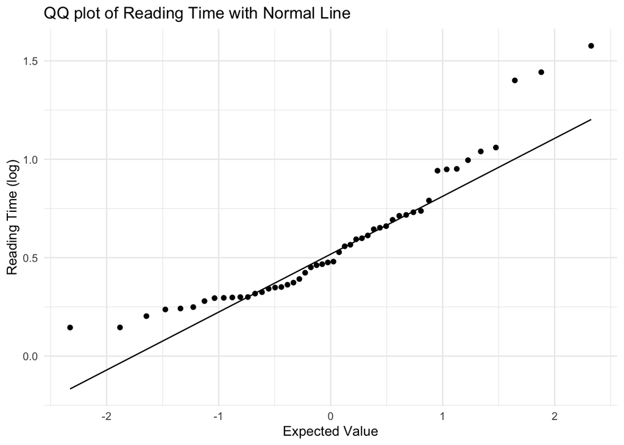

```r
#QQ-plot
ggplot(HJdf, aes(sample = rt)) +
  stat_qq() +
  stat_qq_line() +
  labs(title = "QQ plot of Reading Time with Normal Line",
       y = "Reading Time (log)",
       x = "Expected Value"
       ) +
  theme_minimal()
```

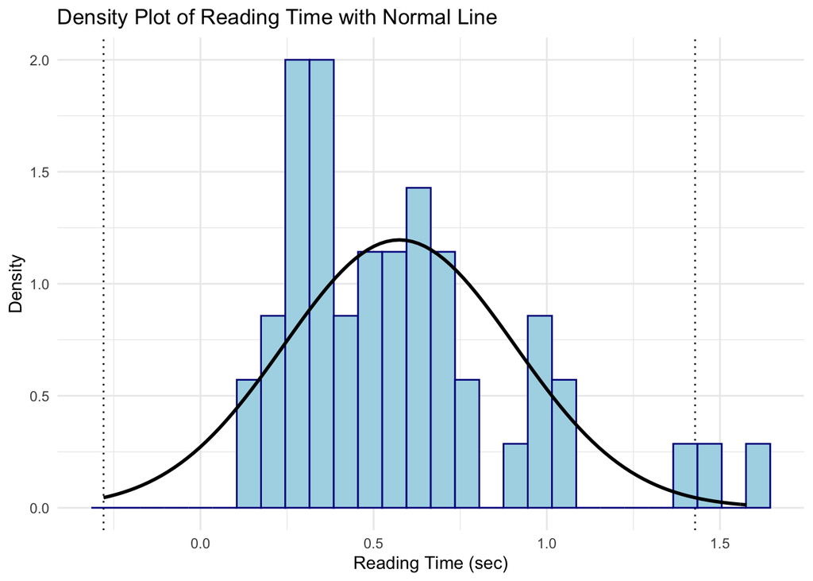

```r
#histogram
ggplot(HJdf, aes(x = rt)) +
  geom_vline(data=HJdf,
             aes(xintercept = mean(rt)+2.56*sd(rt)),
             colour="black",
             linetype="dotted") +
  geom_vline(data=HJdf,
             aes(xintercept = mean(rt)-2.56*sd(rt)),
             colour="black",
             linetype="dotted") +
  geom_histogram(
    aes(y = ..density..),
    color = "darkblue",
    fill = "lightblue",
    binwidth = .07
  ) +
  stat_function(
    fun = dnorm,
    args = list(
      mean = mean(HJdf$rt, na.rm = TRUE),
      sd = sd(HJdf$rt, na.rm = TRUE)
    ),
    colour = "black",
    size = 1
  ) +
  labs(title = "Density Plot of Reading Time with Normal Line",
           y = "Density",
           x = "Reading Time (sec)"
           ) +
  theme_minimal()
```

To summarise, the mean and the median differ by almost 20%, there are possible outliers (2.56 sd from the mean), the skew.2SE exceeds the interval from -1 to 1, and the p-value of the Shapiro-Wilk test is equal to 0.0 - indicating non-normality - so in order to use the t-test, I will have to transform the data:

```r
#transforming data using the natrual logarithm
HJdf$rtLog<- c(log(HJdf$rt))
```

Let’s have a look at the transformed data:

```r
#descriptive statistic
round(stat.desc(HJdf$rtLog, basic = F, norm = T), digits = 2)
```

```
##       median         mean      SE.mean CI.mean.0.95          var
##        -0.74        -0.71         0.08         0.16         0.32
##      std.dev     coef.var     skewness     skew.2SE     kurtosis
##         0.57        -0.80         0.00         0.00        -0.60
##     kurt.2SE   normtest.W   normtest.p
##        -0.45         0.98         0.75
```

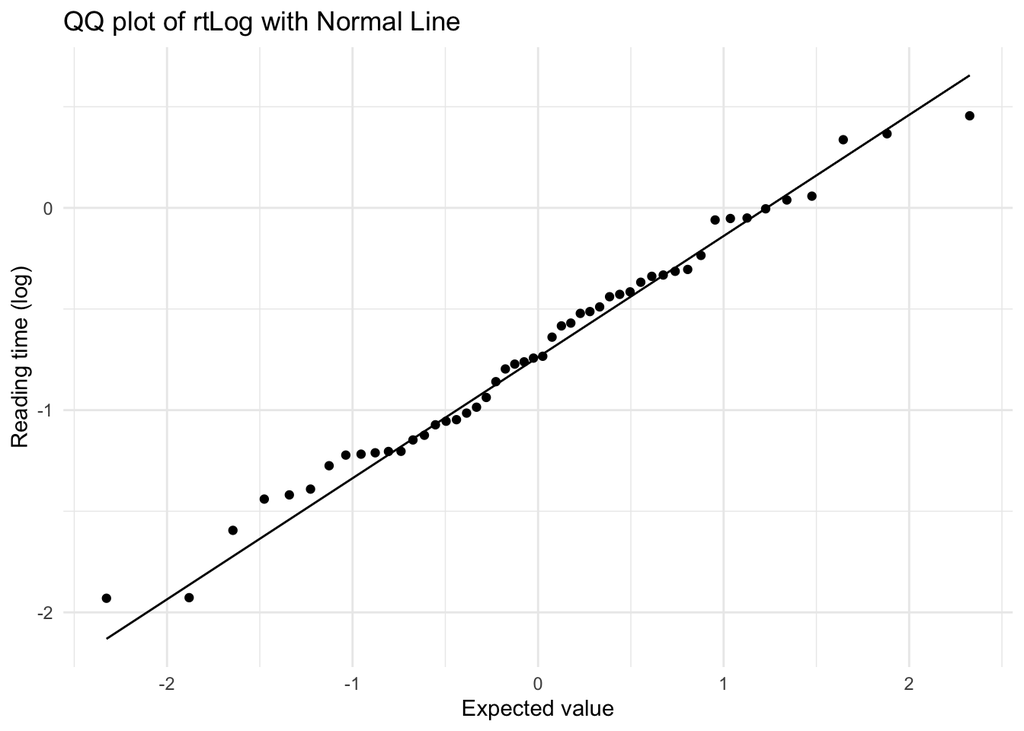

```r
#QQ-plot sqrt'ed data
ggplot(HJdf, aes(sample = rtLog)) +
  stat_qq() +
  stat_qq_line() +
  labs(title = "QQ plot of rtLog with Normal Line",
       y = "Reading time (log)",
       x = "Expected value"
       ) +
  theme_minimal()
```

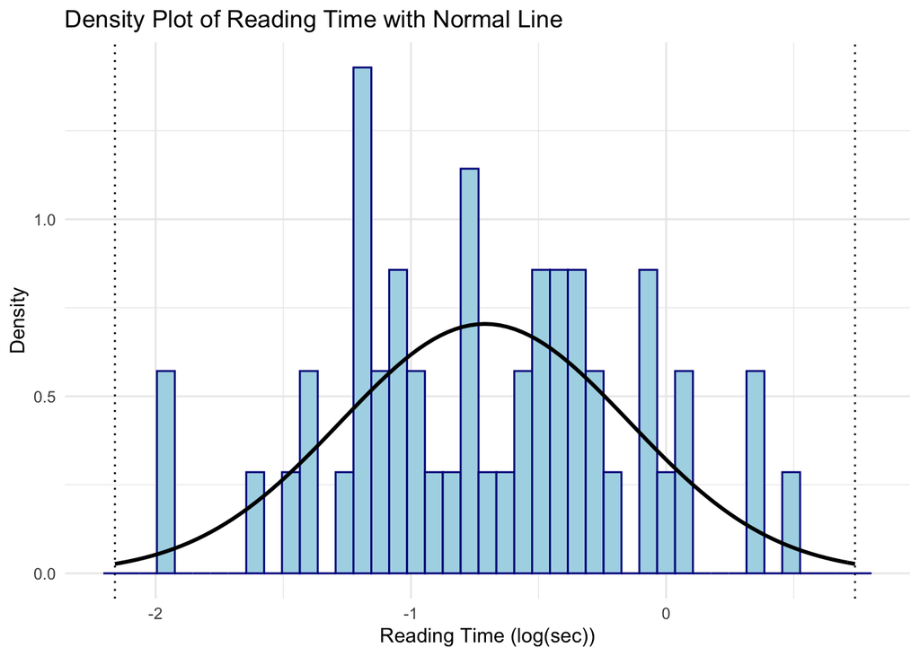

```r
#histogram
ggplot(HJdf, aes(x = rtLog)) +
  geom_vline(data=HJdf,
             aes(xintercept = mean(rtLog)+2.56*sd(rtLog)),
             colour="black",
             linetype="dotted") +
  geom_vline(data=HJdf,
             aes(xintercept = mean(rtLog)-2.56*sd(rtLog)),
             colour="black",
             linetype="dotted") +
  geom_histogram(
    aes(y = ..density..),
    color = "darkblue",
    fill = "lightblue",
    binwidth = .07
  ) +
  stat_function(
    fun = dnorm,
    args = list(
      mean = mean(HJdf$rtLog, na.rm = TRUE),
      sd = sd(HJdf$rtLog, na.rm = TRUE)
    ),
    colour = "black",
    size = 1
  ) +
  labs(title = "Density Plot of Reading Time with Normal Line",
           y = "Density",
           x = "Reading Time (log(sec))"
           ) +
  theme_minimal()
```

Now, the mean and the median are almost equal, there are no posible outliers (2.56 sd from the mean), the skew.2SE and the kurt.2SE are both wihtin the interval from -1 to 1, the p-value of the Shapiro-Wilk test is way above 0.05, and the values on the qq-plot follows the expected line neatly - indicating normality. This means, that I can use the t-test on my data.

I can now run the Welch two sample t-test:

```r
#t-test
t.test(rtLog ~ Stimulus, data = HJdf, paired=FALSE)
```

```
##
##  Welch Two Sample t-test
##
## data:  rtLog by Stimulus
## t = 0.32635, df = 38.595, p-value = 0.7459
## alternative hypothesis: true difference in means is not equal to 0
## 95 percent confidence interval:
##  -0.2773817  0.3840660
## sample estimates:
## mean in group 1 mean in group 2
##      -0.6756107      -0.7289529
```

```r
#finding the standard deviations
H <- filter(HJdf, Stimulus == 1)

J <- filter(HJdf, Stimulus == 2)

Hsd <- sd(H$rtLog)

Jsd <- sd(J$rtLog)

Hsd
```

```
## [1] 0.5327819
```

```r
Jsd
```

```
## [1] 0.5918577
```

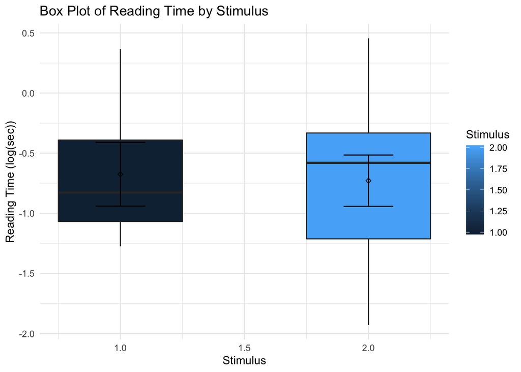

```r
#boxplot
ggplot(HJdf,
       aes(
         x = HJdf$Stimulus,
         y = HJdf$rtLog,
         fill = Stimulus,
         group= Stimulus
       )) +
  geom_boxplot(width = 0.5) +
  stat_summary(
    fun.y = mean,
    geom = "point",
    shape = 23,
    colour = "Black"
  ) +
  geom_errorbar(
    stat = 'summary',
    fun.data = mean_cl_normal,
    width = 0.2
    ) +
  labs(title = "Box Plot of Reading Time by Stimulus",
           y = "Reading Time (log(sec))",
           x = "Stimulus"
           ) +
  theme_minimal()
```

On average, participants who read the salient word was found to use insignificantly differen log(time) (M = -0.73 , SD = 0.59), compared to participants who read the semantically expected word (M = -0.68, SD = 0.53), t(38.595) = 0.32635, p > .05.

This doesn’t tell us much. Let’s convert the rtLog values back to reading times

```r
#defining e
e=2.71828182846

#converting the means back to the original scale
mean1=e^-0.6756107

mean2=e^-0.7289529

#the sd can't just be transformed back like the mean,
#but the boundaries of the confidence interval (boundary=mean±2*sd) can be calculated and converted
#first I calculate the upper and lower boundary of the 95% confidence interval
cilog1h=-0.6756107+0.5327819*1.96
cilog1l=-0.6756107-0.5327819*1.96

#then I converte it to the original scale
ci1h <- e^cilog1h
ci1l <- e^cilog1l

#The same procedure is applied to the values for stimulus 2
cilog2h=-0.7289529+0.5918577*1.96
cilog2l=-0.7289529-0.5918577*1.96

ci2h <- e^cilog2h
ci2l <- e^cilog2l

res <- c(ci1l, mean1, ci1h, ci2l, mean2, ci2h)

res
```

```
## [1] 0.1790906 0.5088456 1.4457697 0.1512239 0.4824139 1.5389313
```

So, on average, participants who read the salient word was found to use insignificantly shorter time (M = 0.48 , CI = 0.15 to 1.54), compared to participants who read the semantically expected word (M = 0.51, CI = 0.18 to 1.45), t(38.595) = 0.32635, p > .05.